# Module 20: Extreme Value Theory

C. Lau

September 28, 2016

## Module 20 Objective

Explain the importance of the tails of distributions, tail correlations and low freq/ high severity events

Demonstrate how extreme value theory can be used to help model risks that have a low probability

Look more closely at the **tails of distributions**

Focus is on considering the modeling of risks with low freq and high sev

Need to be able to recommend a specific approach and choice of **model for the tails** based on a mixture of **quantitative analysis** and **graphical diagnostics**

Should be able to describe how the main theoretical results can be used in practice

## Tail Distributions/ Correlations

Important to model the tail of a distribution accurately due to the potentially devastating impact on companies

### Low Freq/ High Sev Events

*Extreme events*:

- Outcomets that have a **low probability* of occurence but involve** very large sums of money**
- Low frequency $\Rightarrow$ Little data to model their effects accurately
- Occur in the **right hand tail** of the loss distribution
- For insurance:
  - Result of a single cause that has a high financial cost

    (e.g. personal injury claim or complete destruction of a building)
  - Accumulation of events with a related cause

    (e.g. flood damage to a large number of houses in one town)
- Extreme events can occur in contexts other than insurance claims

  e.g. financial losses caused by stock market crash or default of a company on the “credit crunch”

*Example*:

- 2008 credit crisis generated more extreme movements in equity values and credit spreads than had been seen over the 20 years previously
- Oct 19 1987 Black Monday S&P fell by 20.5% (Which is a 1-in-2100 event based on the estimated return period)
- 9/11 and other natural disasters like 2013 Philippines typhoon

*Extreme events should be consider separately*

- Typical risk events fall within the main body of the fitted loss distribution
- Extreme events fall in the right hand tail of the distribution

  Arise through a different cause than the smaller losses

  $\therefore$ They are considered to come from a different statistical distribution
- Important to assess correctly as it involve the highest monetary amounts
- Models of extreme events are important for assessing the impact on a company of unexpected conditions and can help with disaster reovery, business continuity planning etc
- Typically there is a lack of past data on extreme events and so a different approach to modeling needs to be taken

  (e.g. dreaming up “doomsday” type scenarios)

*Challenge of modeling the tail*

1. We can model the tail by modeling the full distribution but need make sure the **form of the distribution is correct in the tails**
   - Use data from both stressed and non-stressed periods to fit the distribution
   - Financial data is typically more **leptokurtic** (narrow peak and fat tail)

     $\therefore$ Extreme values for equity occur more frequently than predicted with a normal distribution
     - A better distribution would be *t* distribution

   **Reasons for fat tails** in financial data
   - **Heteroscedastic** returns (i.e. volatility varies over time)
   - Innovation in a heteroscedastic model are best modeled using a fat tailed distribution
2. **Fitting the tail**
   - Difficult since paramter estimates are **heavily influenced** by the main bulk of the data in the **middle of the distribution**
   - This is where extreme value theory comes can help

## Extreme Value Theory

### Definition of Extreme

1. Consider an extreme value as the **maximum value in a set** of $n$ losses

   **Block maximum**

   e.g. $X_M = max(X_1,X_2,...,X_n)$
2. Consider all losses that exceed a certain **threshold** as being extreme

### Limiting Behaviour

For **losses that have typical sizes** (values from the central part of the distribution) we can use **CLT**:

- *CLT*:

  Standardized value of the average loss $\dfrac{\bar{X} - \mu}{\sigma/\sqrt{n}}$ can be approximated using a normal distribution
  - $\bar{X}$ is the mean of the $n$ samples from a distribution with mean $\mu$ and variance $\sigma$
- Need similar method to estimate the behavior of the extreme values in the tail of the distribution

*Extreme value theory*:

- Has the 2 main results below (maxima and threshold exceedances)
- Key idea is that there are certain families **of distributions** (`Generalized Extreme Value` and `Generalized Pareto`) that **describe the behavior of the tails** of many distributions

#### Maxima

$X_M = max(X_1, X_2,...,X_n)$

- Block maxima
- The distribution of $X_M$ is approximately described by the **Generalized Extreme Value (GEV) family** of distributions
  - If $n$ is sufficiently large
- If we look at a number of such blocks then these maxima can be standardized in a similar way

  i.e. We calculate expressions of the form $\dfrac{X_M - \alpha_n}{\beta_n}$
- Can approximate by an extreme value distribution

#### Threshold Exceedances

$\Pr(X>x+u \mid X>u)$

- The tail of the distribution above a threshold
- Can be approximated, for large values of $u$ by the **Generalized Pareto Distribution** (GPD)
- Consider the expected size of losses that exceed a certain thresholds

## Generalized Extreme Value Distribution

Generalized Extreme Value family of distributions are important in the study of limiting behavior of sample extremes

### Extreme Values Theorem (EVT)

*Distribution* of $X_M$

- $X_M = max(X_1, X_2,...,X_n)$ where each $X_i$ is an observed loss
- If losses are *iid* with CDF $F$:

  $\begin{align} P(X_M \leq x) &= P(X_1 \leq x, X_2 \leq x, ..., X_n \leq x) \\ &= P(X_1\leq x)P(X_2\leq x)...P(X_n \leq x) \\ &= \left[ P(X_1\leq x) \right]^n \\ &= \left[ F(x) \right]^n \\ &= F^n (x)\\ \end{align}$
- Standardized for a sequence of **real constants**

  $\beta_1,...,\beta_n > 0$

  $\alpha_1,...,\alpha_n$
- Consider the limit as $n$ increases:

  Limiting distribution $H(x)$

  $H(x) = \lim \limits_{n \rightarrow \infty} P \left(\dfrac{X_M - \alpha_n}{\beta_n} \leq x \right) = \lim \limits_{n \rightarrow \infty} F^n(\beta_n x + \alpha_n)$

Result **applies for all commonly used statistical distributions** from which the $X_i$ may originate

*Example*

- Determine $H(x)$ where $X_i$ are exponentially distribution (i.e. $F(x) = 1 - e^{-\lambda x}$)

  By setting the following:
  - $\beta = \dfrac{1}{\lambda}$

    (i.e. $\beta_n = \beta$ for all $n$)
  - $\alpha_n = \dfrac{1}{\lambda} \ln(n)$
- Substituting the above into $\beta x + \alpha_n$:

  $\begin{align} F(\beta x + \alpha_n) &= F\left( \dfrac{x + \ln(n)}{\lambda} \right) \\ &= 1 - \exp\left\{-\lambda\left(\dfrac{x + \ln(n)}{\lambda}\right)\right\} \\ &= 1 - \dfrac{1}{n}e^{-x} \\ \end{align}$
- Taking the limit $\rightarrow \infty$

  $\begin{align} \lim \limits_{n \rightarrow \infty} F^n(\beta_n x + \alpha_n) &= \lim \limits_{n \rightarrow \infty} \left( 1 - \dfrac{1}{n}e^{-x} \right)^n & \\ &= e^{-e^{-x}} & \text{since } e^x = \lim \limits_{n \rightarrow \infty} \left( 1 + \dfrac{x}{n}\right)^n \\ \end{align}$

### GEV Distribution

GEV family of distributions havs **3 parameters**

1. $\alpha$: **location** parameter
2. $\beta > 0$: **scale** parameter

   $\alpha$ and $\beta$ just rescale (**shift** and **stretch**) the distribution (similar to mean and s.d.)
3. $\gamma$: **shape** parameter

*CDF of the GEV family*:

$P(X_M \leq x) \approx H(x) \begin{cases} \exp\left\{ -\left( 1 + \dfrac{\gamma(x-\alpha)}{\beta} \right)^{\frac{-1}{\gamma}} \right\} & \gamma \neq 0 \\ \exp\left\{ - \exp\left\{ - \dfrac{(x-\alpha)}{\beta} \right\} \right\} & \gamma = 0\\ \end{cases}$

*Special case*

- CDF of the *standard* GEV distribution has $\alpha=0$ and $\beta =1$

#### Three Forms of GEV

The forms of the GEV family distribution is determined by the sign of $\gamma$ [(+), (-), 0]

*Gumbel GEV*

$\gamma=0$

Tail **falls exponentially**

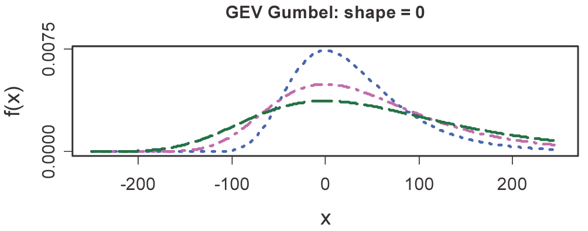

*Weibull GEV*

$\gamma<0$

**Finite upper bound** indicating an absolute maximum

*Application*:

- Distribution of **natural phenomenon**

  e.g. `temperature`, `wind-speed`, `age of human population` etc
- When loss was **certain not to exceed** a certain value

  e.g. reinsured

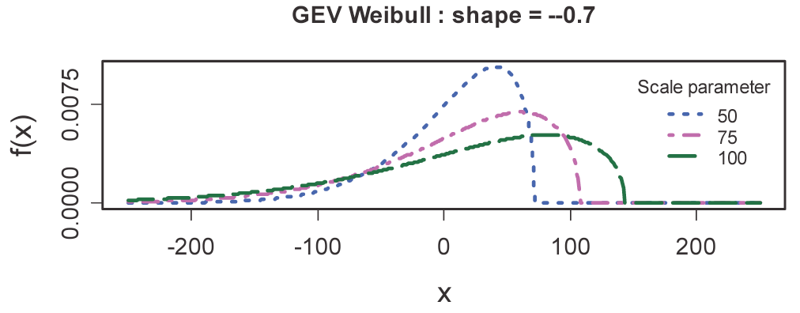

*Fréchet-type GEV*

$\gamma > 0$

**Tails** of the distribution become **heavier**

- Follow a **power** law
- $\gamma > \dfrac{1}{2}$

  $\hookrightarrow$ Infinite variance

*Application*:

- Most suitable for modeling **extreme financial loss events**

Distribution has a *lower bound*:

- Since $x$ takes values such that

  $1 + \dfrac{\gamma{x-\alpha}}{\beta}$

  $\hookrightarrow$ $x - \alpha > \dfrac{-\beta}{\gamma}$

  $\hookrightarrow$ $x > \alpha - \dfrac{\beta}{\gamma}$

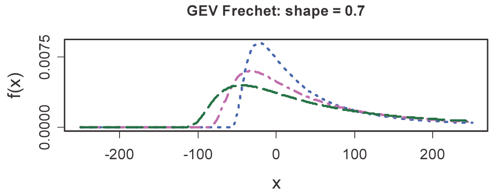

### Underlying Distribution

If we know the form of the **underlying loss distribution** we can work out the limiting distribution of the maximum value ($H(x)$)

$\hookrightarrow$ We can classify the resulting distribution into one of the 3 types based on the sign of $\gamma$

*GEV Distributions* (for the maximum value) corresponding to common loss distributions

| Type | Weibull | Gumbel | Fréchet |
| --- | --- | --- | --- |
| Shape Parameter | $\gamma < 0$ | $\gamma = 0$ | $\gamma >0$ |
| Underlying Distribution | `Beta` `Uniform` `Triangular` | `Chi-square` `Exponential` `Gamma` `Log-normal` `Normal` `Weibull` | `Burr` `F` `Log-gamma` `Pareto` `t` |
| Range of values permitted | $x < \alpha - \dfrac{\beta}{\gamma}$ | $-\infty < x < \infty$ | $x > \alpha - \dfrac{\beta}{\gamma}$ |

*Criteria to predict* which family a particular distribution belongs to

- **Finite upper limits** $\Rightarrow$ Weibull
- **Light tail** + **finite moments** $\Rightarrow$ Gumbel
- **Heavy tail** + **infinite moments** $\Rightarrow$ Fréchet

### Fitting a GEV Distribution

Need to **subdivide data** into groups and calculate the **maximum for each group**

#### Return levels and periods

GEV distribution can be used to analyse a set of observed losses in 2 different ways

1. **Return-level approach**

   Select the maximum observation in each block
2. **Return-period approach**

   Count the observations in each block that exceed some set level

*Number of blocks*

- The **larger** the number of blocks, the fewer observations in each block

  $\hookrightarrow$ Gives **less information about extreme values** (e.g. for approach 1. we get 1-in-100 rather than 1-in-1000)
  - Gives more “extreme” values to fit

    $\hookrightarrow$ **reduces the variance** of the parameter
- The **fewer** blocks (more observation in each block)

  $\hookrightarrow$ more information about the extreme values
  - Variance of parameter estimate is greater

#### Parameterization

One we selected the data, we can estimate the parameters for the GEV distribution using `MLE` or `method of moments`

Using *MLE* to **estimate the parameters** of the GEV distribution

1. *Given*:
   1. Data divided into $m$ blocks of size $n$
   2. Maximum of the $j$<sup>th</sup> block to be $M_{nj}$ (i.e. the maximum data are $M_{n1},...,M_{nm}$)
2. Using the density function of the GEV distribution $h(x)$ to calculate the log-likelihood:

   $\ln\left( L(\gamma, \alpha, \beta; M_n) \right) = \sum \limits_{i=1}^m \ln\left( h(M_{ni}) \right)$
   - Maximize with the following **constraints**:

     $\beta > 0$

     $\left(1 + \gamma \dfrac{M_{ni} - \alpha}{\beta} \right) > 0$

### Advantages/Disadvantages

We can use GEV distributions to investigate the limiting distributions for the minimum values of a distribution

- $H(x)$: limiting dist<sup>n</sup> for the **maximum value** for a particular $\gamma$

  $\hookrightarrow$ $1 - H(-x)$ is the limiting dist<sup>n</sup> for the **minimum value** from the same original dist<sup>n</sup>

*Limitations* of the GEV approach

1. A lot of **data (information) is lost**

   Everything apart from the maxima in each block is effectively ignored
2. Choice of **block size** can be subjective

   Compromise between `granularity` (1-in-100 vs 1-in-1000) and `parameter uncertainty`

## Generalized Pareto Distribution

Consider all claim values **exceed some threshold** as extreme values

- For large samples, the distribution of these extreme values **converges** to the **generalized Pareto distribution** (GPD)
- Need to **select a suitably high threshold** to fit the GPD

### Threshold Exceedances

*Excess distribution over the threshold u* $F_u(x)$

- *Let* $X$ be a r.v. with distribution $F$

  $F_u(x) = P(X - u \leq x \mid X > u) \ = \dfrac{F(x+u) - F(u)}{1 - F(u)}$
  - For $x \leq x < x_F - u$

    *Where* $x_F \leq \infty$ is the right endpoint of $X$

*Generalized Pareto distribution*

- If the losses are *iid*, as the threshold $\uparrow$

  $\hookrightarrow$ The distribution of the conditional losses $\lim \limits_{u \rightarrow \infty} F_u(x)$ will **converge to the GPD** $G(x)$

  $G(x) = \begin{cases} 1 - \left(1+\dfrac{x}{\gamma \beta} \right)^{-\gamma} & \gamma \neq 0 \\ 1 - \exp\left\{ - \dfrac{x}{\beta}\right\} & \gamma = 0\\ \end{cases}$
  - $\beta > 0$: **Scale** parameter
  - $\gamma$: **Shape** parameter
  - CDF of the **standardized GPD** has $\beta = 1$

*Characteristics*

- **Lower bound** when $\gamma > 0$:

  $x \geq 0$
- **Upper bound** when $\gamma < 0$:

  $0 \leq x \leq - \gamma \beta$
- If $\gamma > 0$

  $\hookrightarrow$ GPD becomes the **Pareto distribution**
- **Mean of the GPD**:

  $\mathrm{X} = \dfrac{\gamma \beta}{\gamma -1}$
  - Provided $\gamma > 1$
- If $\gamma >0$

  $\rightarrow$ $\mathrm{E}(X^k) = \infty$ for $k \geq \gamma$

  e.g. if $\gamma \leq 2$ then we have $\mathrm{E}(X^2) = \infty$ (i.e. we have infinite variance)

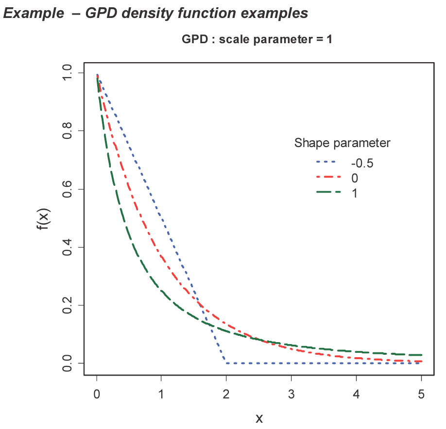

### Asymptotic Property

When the **maxima of a distribution** *converge* to a `GEV distribution`, the **XS distribution** *converges* to a `GPD distribution` (with an equivalent shape parameter $\gamma$)

### Mean XS Function

*Mean XS function* $e(u)$:

$e(u) = \mathrm{E}(X-u \mid X > u)$

- Helps with **fitting a GPD**

*Empirical mean XS function* $e_N(u)$:

$e_N(u) = \dfrac{\sum \limits_{i=1}^N (X_i - u)I(X_i>u)}{\sum \limits_{i=1}^N I(X_i>u)}$

- Calculated for each of the $N$ observed data points by setting $u=X_i$ for $i=1,...,N$

*Mean XS plot*

Each of the observed losses has been treated as a **potential threshold** (on the *x-axis*) and the **mean XS loss** based on that threshold has been calculated and plotted (*y-axis*)

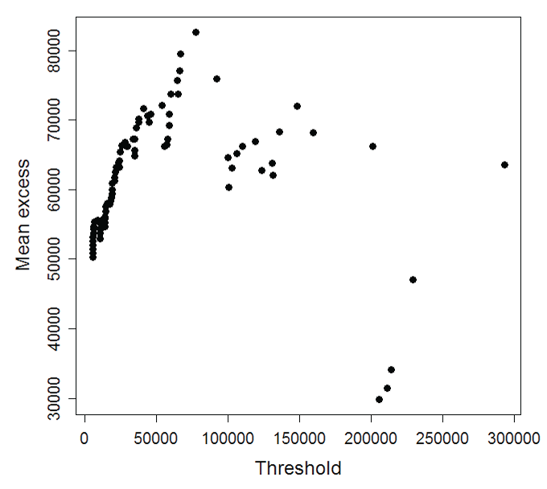

*Example*

Mean XS function for $X\sim Exp(\lambda)$

$\begin{align} F_u(x) &= P(X \leq x + u \mid x >u) & \\ &= P(X \leq x) & \text{Since memoriness} \\ &= F(x)\\ \end{align}$

So the XS distribution is also $Exp(\lambda)$ and the mean XS function is $e(u) = \dfrac{1}{\lambda}$, which is independent of $u$

### Fitting a GPD

Need to **decide on the threshold** $u$, above which we will approximate the underlying distribution with the GPD

- Should consider the **context** when picking $u$

  e.g. XS over which a reinsurer might be liable to cover

  Typically $u$ is around the 90-95<sup>th</sup> percentile of the full distribution

*Consideration* for choosing threshold $u$

- *Trade off* between:

  **Quality of the approximation** to the GPD (good for high $u$)

  *vs*

  **level of bias** in the fit we achieve (good for low $u$)
- For **high value** for $u$
  - The **asymptotic properties apply more accurately** (as we are closer to $\infty$)
  - But have **few data values to work** with (estimates may be unreliable)

Recall (asymptotic property):

- When maxima of a dist<sup>n</sup> ($M_{ni}$) converge to a GEV, then the XS dist<sup>n</sup> ($F_u(x)$) converge to GPD w/ equivalent $\gamma$
- Under the above circumstances $e(u)$ will become a **linear function** of $u$

  $\therefore$ If we **plot** $e(u)$ *against* $u$ we should see linearity appear for higher values of $u$
  - Slope of this line is related to $\gamma$

    $\therefore$ facilitating the **fitting of a GPD** distribution to the **empirical XS distribution**

So to *select a suitable threshold*

- We are looking for the **mean XS** to be **linear** to $u$
- **Graphical test** for tail behavior can then be based on the empirical mean XS function
- Look at the slope of the line
  - Slop upwards $\Rightarrow$ $\gamma$ is (+)
  - Slop downwards $\Rightarrow$ $\gamma$ is (-)

Recall:

- In the $Exp(\lambda)$ example above, the mean XS function was constant (i.e. slope was 0)
- But for other distributions the mean XS function will slope upwards if $\gamma$ is (+) and downwards if $\gamma$ is (-)

*Mean XS simulations*

Below is a selection of mean XS loss plots from simulation

- Each is based on the same underlying $Exp(\lambda)$ distribution

There is a large random element to the plots’ appearance and many of them are far from horizontal (theoretically the slope should be 0)

Therefore selecting a suitable threshold (and value of $\gamma$) is very difficult

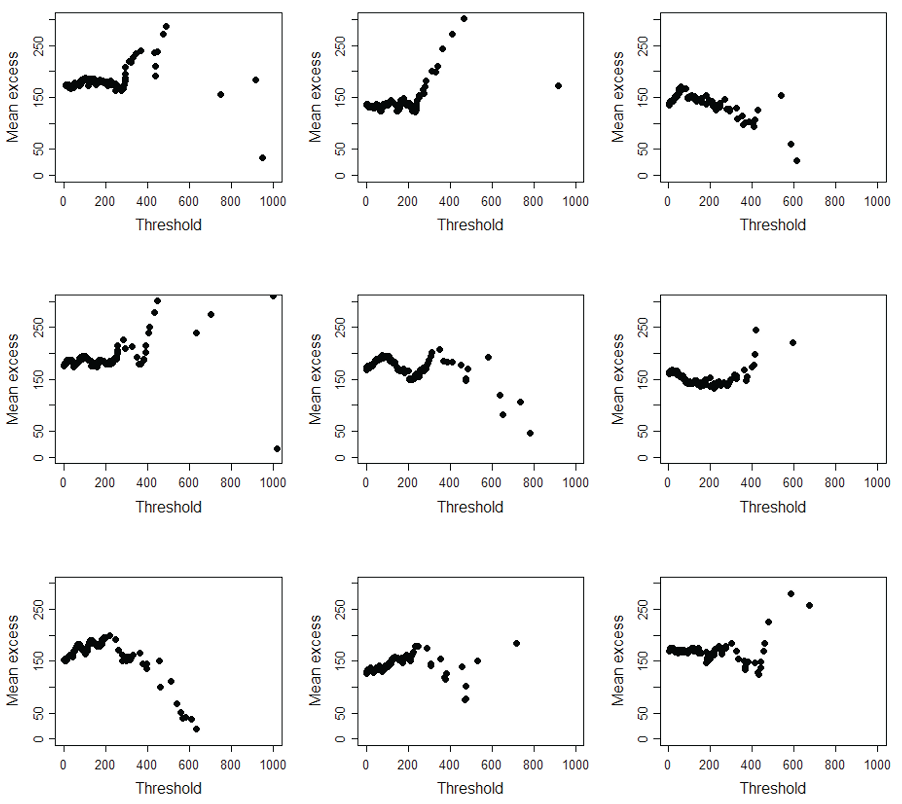

*Example*

Based on the sample mean XS plot (from the mean XS function section)

Below shows the **different possibilities for choosing** the threshold

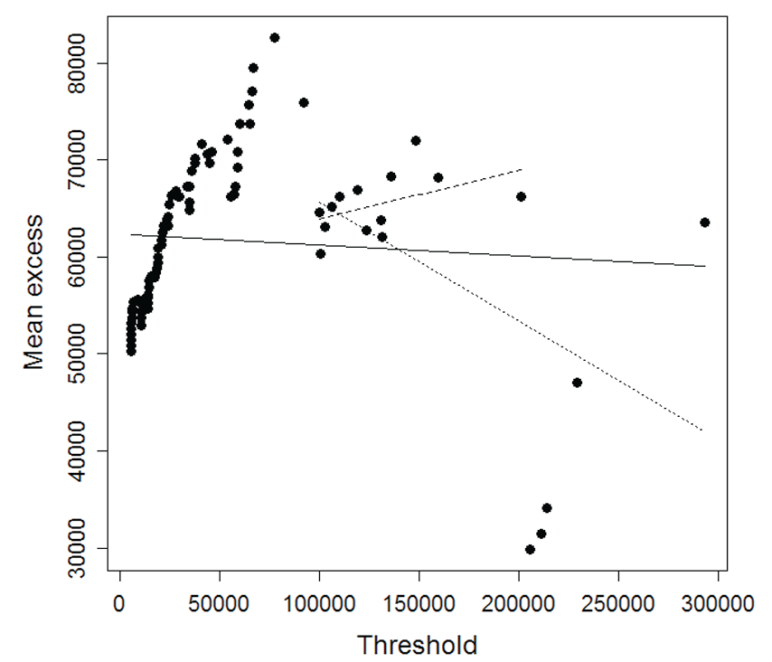

1. Longest (solid) line is the least squares linear regression on the whole data set
2. Shorter (dotted) line is a regression on just the tail (above 100,000)
3. Shortest (dashed) line is a regression on the tail (above 100,000) excluding the final five points

This again, shows the **subjectivity** in the fitting process

#### Parameterization

Above the chosen threshold, we can fit a GPD by using standard techniques (e.g. `MLE`, `Method of moments`) to calculate $\gamma$ and $\beta$

*MLE Example*

- Data before cut off $X = \{X_1,...,X_n\}$ is assumed to be *iid*
- $Y_j = X_j - u$ is the amount of the XS loss when the threshold is exceeded
  - *Assume* $Y_j$ follow a GPD, not the $X_j$
- Assume a random number of observations $N_u$ exceed the threshold
- If we attempt to fit a GPD with parameters $\gamma$ and $\beta$ and PDF $g(x)$ to the data $(Y_1, Y_2, ...,Y_n)$ then we get the following log-likelihood function:

  $\ln \left( L(\gamma,\beta; Y) \right) = \sum \limits_{j=1}^{N_u} \ln \left( g(Y_j) \right)$

**Domain** of valid values for $x$ will **depend*8 on the values of the parameters $\gamma$ and $\beta$